# DFS Parentheses Theorem

Edit the RMarkdown source file for this assignment in RStudio. When you finish, Knit the file to HTML and upload the `.html` output to Canvas.

For this assignment, we will use the following version of depth-first search.

```
DFS(v, clock):
    mark v
    clock <- clock + 1; v.pre <- clock
    for each edge vw
        if w is unmarked
            w.parent <- v
            clock <- DFS(w, clock)
    clock <- clock + 1; v.post <- clock
    return clock
```

Suppose the `DFS` algorithm is called on the following graph as `DFS(v1, 0)`. When a vertex `v` has more than one outgoing edge `vw`, assume that the `for`-loop considers the vertices `w` $=v_i$ in order of subscript.

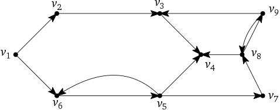

1. Give the discovery time `v.pre` and finish time `v.post` for each vertex.
2. Use ASCII art to create a number line figure illustrating the active intervals for each vertex, like the one in Figure 6.4 on p. 229 of [E]. (The interval for `v1` is done for you.)

```
[-------------------------v1-----------------------]





1  2  3  4  5  6  7  8  9  10 11 12 13 14 15 16 17 18 19 20
```

3. Classify each edge as *tree edge*, *forward edge*, *back edge*, or *cross edge*.
4. List the vertices in the order of a *preorder* traversal and also in the order of a *postorder* traversal.
5. Find two vertices $v_i$ and $v_j$ such that the trees produced by `DFS(v_i,0)` and `DFS(v_j,0)` overlap, but in a way such that neither tree is contained in the other.